# ANALISIS EKSTRAKSI CIRI SINYAL DOMAIN WAKTU DAN FREKUENSI PADA SUARA SENJATA API

## Mata Kuliah Analisis Sinyal Digital 119

- Dosen Pengampu : Haris Suhendar, M.Sc, Dr. Bambang Heru Iswanto, M.Si
- Nama : Difa Farhani Hakim (1306620040)
- Kelas : Fisika - B
- Angkatan : 2020

# Import Modul

```python
# !python -m pip install spafe
# !pip install spafe
```

```python
import numpy as np
import matplotlib.pyplot as plt
import seaborn as sns
import pandas as pd

import librosa
from IPython.display import Audio
import spafe.features.pncc as pncc_lib
from sklearn.decomposition import PCA
from sklearn.preprocessing import StandardScaler

import sys
import os
```

# Load dan Zip Dataset

Source dataset kaggle: https://www.kaggle.com/datasets/emrahaydemr/gunshot-audio-dataset/

Link download dataset: https://unjac-my.sharepoint.com/:u:/g/personal/difafarhanihakim_1306620040_mhs_unj_ac_id/EaRFSObt29VLgTGr7ecOh-4B6bf2Dlik4RSo-nc2sHOJKw?e=vcViRJ

```python
path = "dataset/"
dir_list = os.listdir(path)
print(dir_list)
```

```
['AK-12', 'AK-47', 'IMI Desert Eagle', 'M16', 'M249', 'M4', 'MG-42', 'MP5', 'Zastava M92']
```

```python
num_sample = 10
path_list = []
path_list2 = []
for i in dir_list:
    path2 = os.listdir(path +'/'+ i)
    path2.sort()
    for j in path2[:num_sample]:
        path3 = i +'/'+ j
        path_list.append(i)
        path_list2.append(path3)

print(path_list[:5])
print(path_list2[:5])
```

```
['AK-12', 'AK-12', 'AK-12', 'AK-12', 'AK-12']
['AK-12/3 (1).wav', 'AK-12/3 (10).wav', 'AK-12/3 (11).wav', 'AK-12/3 (12).wav', 'AK-12/3 (13).wav']
```

```python
data = []
waktu = []
sr = []
no = 0
for i in path_list2:
    data_temp, sr_temp = librosa.load(path + '/' +  i)
    waktu_temp = librosa.get_duration(y=data_temp, sr=sr_temp)
    if no % num_sample == 0:
        print(i)
        display(Audio(data=data_temp,rate=sr_temp))

    data.append(data_temp)
    sr.append(sr_temp)
    waktu.append(waktu_temp)
    no += 1
print('Data loaded:',no)
```

```
AK-12/3 (1).wav
```

[interactive chart not shown]

```
AK-47/1 (1).wav
```

[interactive chart not shown]

```
IMI Desert Eagle/2 (1).wav
```

[interactive chart not shown]

```
M16/5 (1).wav
```

[interactive chart not shown]

```
M249/6 (1).wav
```

[interactive chart not shown]

```
M4/4 (1).wav
```

[interactive chart not shown]

```
MG-42/7 (1).wav
```

[interactive chart not shown]

```
MP5/8 (1).wav
```

[interactive chart not shown]

```
Zastava M92/9 (1).wav
```

[interactive chart not shown]

```
Data loaded: 90
```

```python
data_load = {
    'Kelas' : path_list,
    'Nama File' : path_list2,
    'Waktu' : waktu,
    'Sample Rate': sr,
       }
df_load = pd.DataFrame(data_load)
df_load
```

|  | Kelas | Nama File | Waktu | Sample Rate |
| --- | --- | --- | --- | --- |
| 0 | AK-12 | AK-12/3 (1).wav | 2.0 | 22050 |
| 1 | AK-12 | AK-12/3 (10).wav | 2.0 | 22050 |
| 2 | AK-12 | AK-12/3 (11).wav | 2.0 | 22050 |
| 3 | AK-12 | AK-12/3 (12).wav | 2.0 | 22050 |
| 4 | AK-12 | AK-12/3 (13).wav | 2.0 | 22050 |
| ... | ... | ... | ... | ... |
| 85 | Zastava M92 | Zastava M92/9 (14).wav | 1.0 | 22050 |
| 86 | Zastava M92 | Zastava M92/9 (15).wav | 1.0 | 22050 |
| 87 | Zastava M92 | Zastava M92/9 (16).wav | 1.0 | 22050 |
| 88 | Zastava M92 | Zastava M92/9 (17).wav | 1.0 | 22050 |
| 89 | Zastava M92 | Zastava M92/9 (18).wav | 1.0 | 22050 |

90 rows × 4 columns

# Ekstraksi Ciri Energy, ZCR, Energy of Entropy, MFCC, dan PNCC

```python
def energy1(data):
    output = np.sum(np.abs(data**2))
    return output

def zcr1(data):
    N = len(data)
    data2 = data[0:-1]
    data2 = np.insert(data2, 0, 0)
    a = np.sign(data)
    b = np.sign(data2)
    zc = np.sum(np.abs(a - b))/2
    zcr_ = zc/N
    return zcr_

def entropy_energy(frame, k=10):
    E_short = energy1(frame)
    frame_len = len(frame)
    sub_win_len = int(frame_len/k)
    e_j = []
    for i in range(0,frame_len,sub_win_len):
        E_sub = energy1(frame[i:i+sub_win_len])
        E_divide = E_sub/E_short
        e_j.append(E_divide)

    H_i = - np.sum(e_j * np.log2(e_j))
    return H_i
```

```python
energy_list = []
zcr_list = []
eoe_list = []
mfcc_list = []
pncc_list = []
N = len(data)
for i in range(N):
    data_input = data[i]
    N_data = len(data[i])

    energy_0 = energy1(data_input)
    zcr_0 = zcr1(data_input)
    eoe_0 = entropy_energy(data_input,k=10)
    mfcc_0 = np.mean(librosa.feature.mfcc(y=data_input, n_mfcc=13, hop_length = N_data+1))
    pncc_0 = np.mean(pncc_lib.pncc(sig=data_input, nfft=N_data+1, fs=N_data+1))

    energy_list.append(energy_0)
    zcr_list.append(zcr_0)
    eoe_list.append(eoe_0)
    mfcc_list.append(mfcc_0)
    pncc_list.append(pncc_0)
```

## Membuat List Ciri

```python
data_pd = {
    'Kelas' : path_list,
    'Nama File' : path_list2,
    'Energy': energy_list,
    'ZCR': zcr_list,
    'EoE': eoe_list,
    'MFCC': mfcc_list,
    'PNCC': pncc_list,
       }
df = pd.DataFrame(data_pd)
df
```

|  | Kelas | Nama File | Energy | ZCR | EoE | MFCC | PNCC |
| --- | --- | --- | --- | --- | --- | --- | --- |
| 0 | AK-12 | AK-12/3 (1).wav | 1044.180786 | 0.153866 | 2.775766 | -36.055309 | 0.230036 |
| 1 | AK-12 | AK-12/3 (10).wav | 1446.640869 | 0.191803 | 3.095031 | 0.845041 | 0.235556 |
| 2 | AK-12 | AK-12/3 (11).wav | 225.114731 | 0.128583 | 1.058286 | -11.705831 | 0.169762 |
| 3 | AK-12 | AK-12/3 (12).wav | 1088.407227 | 0.170918 | 2.739360 | -37.543819 | 0.229652 |
| 4 | AK-12 | AK-12/3 (13).wav | 1200.696777 | 0.154932 | 2.874003 | -13.768671 | 0.232243 |
| ... | ... | ... | ... | ... | ... | ... | ... |
| 85 | Zastava M92 | Zastava M92/9 (14).wav | 537.527954 | 0.114036 | 3.302777 | 5.702017 | 0.309107 |
| 86 | Zastava M92 | Zastava M92/9 (15).wav | 865.876953 | 0.128458 | 3.234779 | 6.980283 | 0.316747 |
| 87 | Zastava M92 | Zastava M92/9 (16).wav | 557.040955 | 0.159977 | 3.317926 | 1.940660 | 0.307975 |
| 88 | Zastava M92 | Zastava M92/9 (17).wav | 576.020325 | 0.171361 | 3.313111 | 1.680705 | 0.303595 |
| 89 | Zastava M92 | Zastava M92/9 (18).wav | 877.008118 | 0.147959 | 3.237194 | 8.706468 | 0.312235 |

90 rows × 7 columns

```python
unique_classes = np.unique(df['Kelas'])
num_unique = len(unique_classes)
print('Total number of outputs : \n', unique_classes)
print('Output classes : ', num_unique)
```

```
Total number of outputs :
 ['AK-12' 'AK-47' 'IMI Desert Eagle' 'M16' 'M249' 'M4' 'MG-42' 'MP5'
 'Zastava M92']
Output classes :  9
```

# Principle Component Analysis

```python
target = df['Kelas']
df_fit = df.drop(['Kelas','Nama File'], axis='columns')
```

```python
df_fit_standard = StandardScaler().fit_transform(df_fit)
pca_standard = PCA(n_components = 2)
data_PCA_standard = pca_standard.fit_transform(df_fit_standard)
```

## Scree Plot

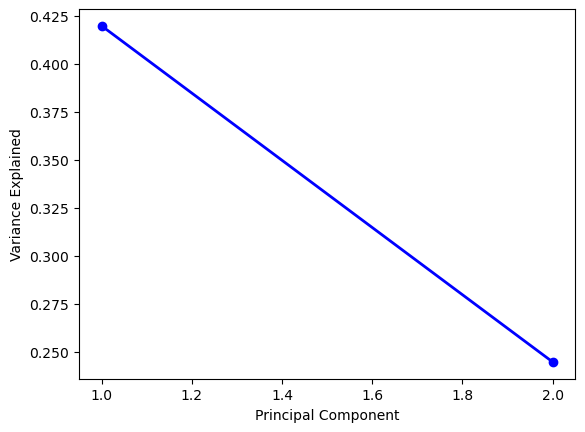

```python
PC_values = np.arange(pca_standard.n_components_) + 1
plt.plot(PC_values, pca_standard.explained_variance_ratio_,
         'o-', linewidth=2, color='blue')

plt.xlabel('Principal Component')
plt.ylabel('Variance Explained')
plt.show()
```

```python
print('Explained variation per principal component: {}'.format(pca_standard.explained_variance_ratio_))
```

```
Explained variation per principal component: [0.41966535 0.24463532]
```

Dari hasil tersebut menandakan bahwa PCA1 mewakili sampel data sebesar 41.96%, sedangkan pada PCA2 mewakili sampel data sebesar 24.46%. Dari kedua PCA tersebut diperoleh bahwa 33.58% informasi data telah hilang.

## Hasil PCA pada ekstraksi ciri

```python
pca_comp = pca_standard.components_.transpose()
list_ciri = ['Energy','ZCR','EoE','MFCC','PNCC']
data_comp = {
    'Ciri': list_ciri,
    'PCA1': pca_comp[:,0],
    'PCA2': pca_comp[:,1],
       }
df_comp = pd.DataFrame(data_comp)
df_comp
```

|  | Ciri | PCA1 | PCA2 |
| --- | --- | --- | --- |
| 0 | Energy | -0.361424 | 0.385011 |
| 1 | ZCR | -0.272838 | 0.688400 |
| 2 | EoE | -0.600188 | 0.094492 |
| 3 | MFCC | -0.371671 | -0.471795 |
| 4 | PNCC | -0.544580 | -0.382560 |

```python
df_comp.sort_values(by=['PCA1'])
```

|  | Ciri | PCA1 | PCA2 |
| --- | --- | --- | --- |
| 2 | EoE | -0.600188 | 0.094492 |
| 4 | PNCC | -0.544580 | -0.382560 |
| 3 | MFCC | -0.371671 | -0.471795 |
| 0 | Energy | -0.361424 | 0.385011 |
| 1 | ZCR | -0.272838 | 0.688400 |

Pada PCA1 mengukur variasi berdasarkan EoE dan PNCC, sehingga bertambahnya nilai EoE dan PNCC akan memberi dampak pada ciri yang lain. Selain itu, Pada PCA1 memiliki korelasi keterbalikan dengan semua ciri ditandai dengan nilai PCA1 yang negatif pada setiap ciri.

```python
df_comp.sort_values(by=['PCA2'])
```

|  | Ciri | PCA1 | PCA2 |
| --- | --- | --- | --- |
| 3 | MFCC | -0.371671 | -0.471795 |
| 4 | PNCC | -0.544580 | -0.382560 |
| 2 | EoE | -0.600188 | 0.094492 |
| 0 | Energy | -0.361424 | 0.385011 |
| 1 | ZCR | -0.272838 | 0.688400 |

Pada PCA2 mengukur variasi berdasarkan MFCC dan ZCR. PCA2 memiliki korelasi pada rendahnya ciri MFCC dan tingginya ciri ZCR.

## Hasil PCA pada setiap sampel data

```python
data_PCA = {
    'Nama File' : path_list2,
    'PCA1': data_PCA_standard[:,0],
    'PCA2': data_PCA_standard[:,1],
       }
df_PCA = pd.DataFrame(data_PCA)
df_PCA
```

|  | Nama File | PCA1 | PCA2 |
| --- | --- | --- | --- |
| 0 | AK-12/3 (1).wav | 1.169666 | 1.374381 |
| 1 | AK-12/3 (10).wav | -0.528279 | 0.571548 |
| 2 | AK-12/3 (11).wav | 3.189182 | 0.295713 |
| 3 | AK-12/3 (12).wav | 1.162742 | 1.631653 |
| 4 | AK-12/3 (13).wav | 0.366680 | 0.615526 |
| ... | ... | ... | ... |
| 85 | Zastava M92/9 (14).wav | -1.257534 | -1.404310 |
| 86 | Zastava M92/9 (15).wav | -1.486232 | -1.277042 |
| 87 | Zastava M92/9 (16).wav | -1.359299 | -0.731162 |
| 88 | Zastava M92/9 (17).wav | -1.344481 | -0.547245 |
| 89 | Zastava M92/9 (18).wav | -1.567243 | -1.073528 |

90 rows × 3 columns

```python
df_PCA.sort_values(by=['PCA1'])
```

|  | Nama File | PCA1 | PCA2 |
| --- | --- | --- | --- |
| 49 | M249/6 (18).wav | -2.942781 | 1.218338 |
| 11 | AK-47/1 (10).wav | -2.549370 | 2.143396 |
| 12 | AK-47/1 (11).wav | -2.451161 | 2.311179 |
| 62 | MG-42/7 (100).wav | -2.423194 | 1.097180 |
| 17 | AK-47/1 (16).wav | -2.409883 | 3.249113 |
| ... | ... | ... | ... |
| 16 | AK-47/1 (15).wav | 2.084632 | 0.727010 |
| 70 | MP5/8 (1).wav | 2.236434 | -0.575000 |
| 27 | IMI Desert Eagle/2 (15).wav | 2.368623 | -1.504423 |
| 2 | AK-12/3 (11).wav | 3.189182 | 0.295713 |
| 28 | IMI Desert Eagle/2 (16).wav | 3.514673 | -0.835984 |

90 rows × 3 columns

Pada PCA 1 nilai terendah ada pada M249 dan AK-47, sedangkan nilai tertinggi ada pada IMI Desert Eagle dan AK-12. Hal tersebut menandakan bahwa variasi pada PCA1 bergantung pada kedua tipe jenis senjata api tersebut.

```python
df_PCA.sort_values(by=['PCA2'])
```

|  | Nama File | PCA1 | PCA2 |
| --- | --- | --- | --- |
| 80 | Zastava M92/9 (1).wav | -1.990476 | -1.833612 |
| 52 | M4/4 (100).wav | -0.491922 | -1.778495 |
| 32 | M16/5 (100).wav | -0.491922 | -1.778495 |
| 84 | Zastava M92/9 (13).wav | -1.192943 | -1.539727 |
| 27 | IMI Desert Eagle/2 (15).wav | 2.368623 | -1.504423 |
| ... | ... | ... | ... |
| 12 | AK-47/1 (11).wav | -2.451161 | 2.311179 |
| 19 | AK-47/1 (18).wav | -1.448744 | 2.345370 |
| 14 | AK-47/1 (13).wav | -0.643670 | 2.777835 |
| 18 | AK-47/1 (17).wav | -2.393353 | 2.845548 |
| 17 | AK-47/1 (16).wav | -2.409883 | 3.249113 |

90 rows × 3 columns

Pada PCA2 nilai terendah ada pada Zastava, sedangkan nilai tertinggi ada pada AK-47. Hal tersebut menandakan bahwa variasi pada PCA2 bergantung pada tipe senjata api yang memiliki kesamaan dengan Zastava atau dengan AK-47.

```python
pc12_standard = pd.DataFrame(data = data_PCA_standard, columns = ['pca1', 'pca2'])
pc12_standard['target'] = target
```

## Plot Persebaran Data

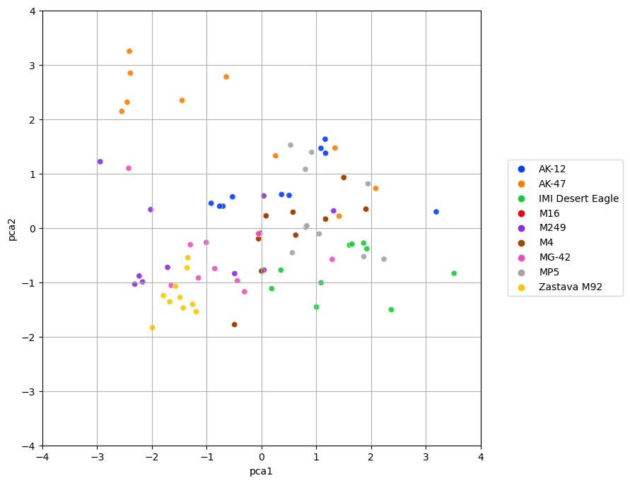

```python
plt.figure(figsize=(8,8))
splot = sns.scatterplot(
    x = "pca1", y="pca2",
    hue = "target",
    palette = sns.color_palette("bright", num_unique),
    data = pc12_standard,
    alpha = 0.9
)
splot.legend(loc='center left', bbox_to_anchor=(1.05, 0.5), ncol=1)
splot.set_xlim(-4,4)
splot.set_ylim(-4,4)
plt.grid()
```

# Referensi

- Buku Giannakopoulos - Introduction to Audio Analysis
- PNCC : https://spafe.readthedocs.io/en/latest/features/pncc.html
- PCA :
  - https://www.datacamp.com/tutorial/principal-component-analysis-in-python
  - https://www.datacamp.com/tutorial/pca-analysis-r
  - https://jakevdp.github.io/PythonDataScienceHandbook/05.09-principal-component-analysis.html
  - https://online.stat.psu.edu/stat505/lesson/11